# Problem Set 5

Ananth Josyula

Due Date: 2022/10/09 @ 11:59PM CST

## Getting Set Up

If you haven’t already, create a folder for this course, and then a subfolder within for the second lecture `Topic7_ConditionalVariation`, and two additional subfolders within `code` and `data`.

Open `RStudio` and create a new RMarkDown file (`.Rmd`) by going to `File -> New File -> R Markdown...`. Change the title to `"DS1000: Problem Set 5"` and the author to your full name. Save this file as `[LAST NAME]_ps5.Rmd` to your `code` folder.

If you haven’t already, download the `Pres2020_PV.Rds` and `Pres2020_StatePolls.Rds` file from the course [github page](https://github.com/jbisbee1/DSCI1000/blob/main/Lectures/Topic7_ConditionalVariation/data/) and save it to your `data` folder. Then require `tidyverse` and load the `Pres2020_PV.Rds` data to `pres`.

```r
# INSERT CODE HERE
require(tidyverse)
pres <- readRDS("../data/Pres2020_PV.rds")
```

## Question 1 [3 points]

What is the relationship between the margin of error (`MoE`) and the sample size (`SampleSize`)? Choose the appropriate plot and describe your answer in a few sentences. Make sure to label the figure thoroughly. EXTRA CREDIT: make a sensible decision about how to handle the skew in the data and defend your choice.

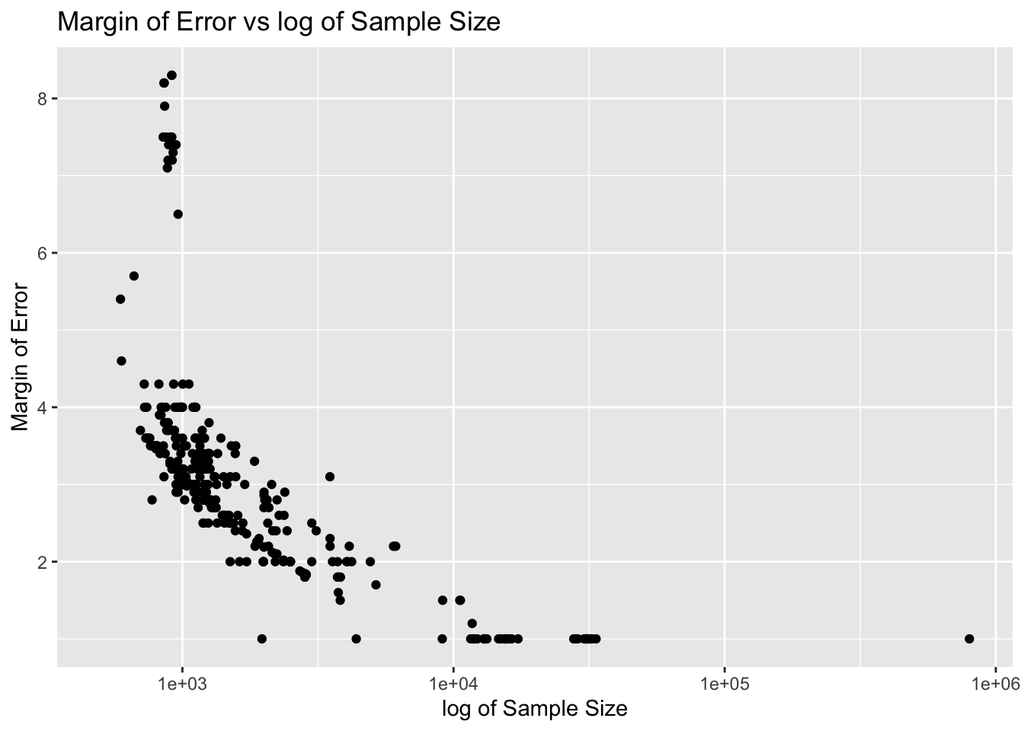

```r
# INSERT CODE HERE
pres_raw <- pres
pres_raw %>%
  ggplot(aes(x=SampleSize, y=MoE)) + scale_x_log10() + geom_point() +
  labs(title = 'Margin of Error vs log of Sample Size', x = 'log of Sample Size', y = 'Margin of Error')
```

> - Based on the logged graph above, as the sample size increases, the margin of error decreases. One way to handle the skew could be to remove the outlier with a very large sample size or could be to identify the 1st and 3rd quartile and only graph data between those values.

## Question 2 [3 points]

Calculate the weighted average of Biden and Trump’s support via the `weighted.mean()` function. Try using both the sample size (`SampleSize`) as weights or the inverse of the margin of error (`1/MoE`). Compare these estimates to the unweighted estimate. Which is more accurate? NB: you will have to make a decision about how to handle polls that don’t report their margin of error or sample size. Describe and justify your decision.

```r
# INSERT CODE HERE
pres_raw %>%
  filter(!is.na(SampleSize)) %>%
  summarise(bidenSWeighted = weighted.mean(Biden,w = SampleSize),
            trumpSWeighted = weighted.mean(Trump,w = SampleSize))
```

```
## # A tibble: 1 × 2
##   bidenSWeighted trumpSWeighted
##            <dbl>          <dbl>
## 1           50.2           43.1
```

```r
pres_raw %>%
  filter(!is.na(MoE)) %>%
  summarise(bidenMoeWeighted = weighted.mean(Biden,w = 1/MoE),
            trumpMoeWeighted = weighted.mean(Trump,w = 1/MoE))
```

```
## # A tibble: 1 × 2
##   bidenMoeWeighted trumpMoeWeighted
##              <dbl>            <dbl>
## 1             49.1             41.6
```

```r
pres_raw %>%
  summarise(bidenUnweight = mean(Biden, na.rm = T),
            trumpUnweight = mean(Trump, na.rm = T))
```

```
## # A tibble: 1 × 2
##   bidenUnweight trumpUnweight
##           <dbl>         <dbl>
## 1          49.3          41.2
```

> - Based on both weighted samples and the unweighted sample, the weighted by sample size is most accurate. This is because its values for both Biden and Trump based on weighting by sample size of 50.16537 and 43.06868 respectively are very close to the actual vote count of 51 for Biden and 47 for Trump. NA entries were removed when calculating the mean for both weighted and unweighted.

## Question 3 [4 points]

Did national polls fielded on or after September 1st over-estimate Biden’s support and underestimate Trump’s support? Answer the question using bootstrap simulations that randomly sample every poll with replacement (`sample_n(size = nrow(.), replace = T)`) to express your confidence in your conclusion. Save your bootstrapped results to an object named `bs_Nation_Vanilla`. Plot the simulated results with two histograms on the same plot, using red for Trump and blue for Biden, and overlay vertical lines showing their true vote shares (red dashed lines for Trump and blue dashed lines for Biden). Make sure to label your figure thoroughly.

```r
# INSERT CODE HERE
pres_raw <- pres %>%
  mutate(StartDate = as.Date(StartDate, format="%m/%d/%Y")) %>%
  filter(StartDate >= as.Date("2020-09-01"))

set.seed(123)
bs_Nation_Vanilla <- NULL

for(i in 1:1000) {
  bs_Nation_Vanilla <- pres_raw %>%
  sample_n(size = nrow(.), replace=T) %>%
  summarise(meanBiden = mean(Biden, na.rm = T), meanTrump = mean(Trump, na.rm = T)) %>%
  bind_rows(bs_Nation_Vanilla)
}

bs_Nation_Vanilla %>%
  summarise(conBiden = mean(meanBiden > 51, na.rm=T), conTrump = mean(meanTrump < 47, na.rm=T))
```

```
## # A tibble: 1 × 2
##   conBiden conTrump
##      <dbl>    <dbl>
## 1    0.084        1
```

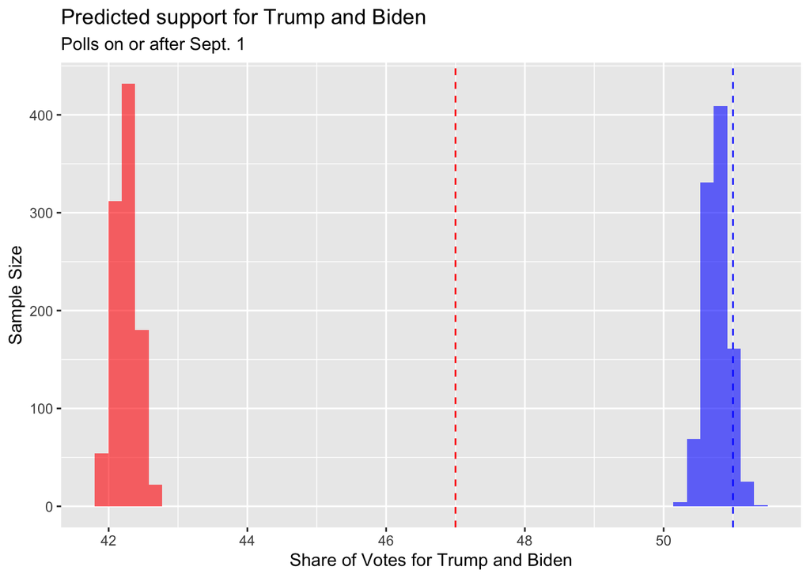

```r
plot_final <- bs_Nation_Vanilla %>%
  ggplot(aes(x=StartDate))+
  geom_histogram(aes(x=meanBiden), fill = 'blue', bins=50, alpha=0.6) +
  geom_histogram(aes(x=meanTrump), fill = 'red', bins=50, alpha=0.6) +
  geom_vline(xintercept = 47, linetype = 'dashed', color='red') +
  geom_vline(xintercept = 51, linetype = 'dashed', color='blue') +
  labs(title = 'Predicted support for Trump and Biden',
       subtitle = 'Polls on or after Sept. 1',
       x='Share of Votes for Trump and Biden',
       y='Sample Size')

plot_final
```

> - Based on the simulation, the polls conducted on or after September 1 underestimated Trump’s support with 100% confidence. Meanwhile, they overestimated Biden’s support with 8.4% confidence.

## Question 4 [4 points]

Re-estimate the preceding question, but this time calculate the weighted average of support for Biden and Trump using the best weights as identified in Question 2 above. Save your bootstrapped results to an object named `bs_Nation_Wgt`. Does your *confidence* change from the previous question? Which set of results are more accurate?

```r
# INSERT CODE HERE
pres_raw <- pres %>%
  mutate(StartDate = as.Date(StartDate, format='%m/%d/%Y')) %>%
  filter(StartDate >= as.Date("2020-09-01"))

set.seed(123)
bs_Nation_Wgt  <- NULL

for(i in 1:1000) {
  bs_Nation_Wgt <- pres_raw %>%
  sample_n(size = nrow(.), replace = T) %>%
  summarise(meanTrump = weighted.mean(Trump, w=SampleSize,na.rm=T), meanBiden = weighted.mean(Biden, w=SampleSize, na.rm=T)) %>%
  bind_rows(bs_Nation_Wgt)
}

pres_final <- bs_Nation_Wgt %>%
  summarise(conBiden = mean(meanBiden > 51, na.rm=T), conTrump = mean(meanTrump < 47, na.rm=T))

pres_final
```

```
## # A tibble: 1 × 2
##   conBiden conTrump
##      <dbl>    <dbl>
## 1    0.979        1
```

> - Based on the the weighted average of support for Biden and Trump using weights by sample size as identified in question 2, while the Trump confidence remains constant, the Biden confidence increases from 8.4% to 97.9%. Since 8.4 is closer to 51 and both Trump confidences are the same, bs_Nation_Vanilla seems more accurate.